# Why the world is pro-Palestinian ?

Some thoughts on credulity and dynamics of beliefs

Gilbert PC

19/10/2014

*Belief is the central problem in the analysis of mind. Believing seems the most «mental» thing we do, the thing most remote from what is done by mere matter. The whole intellectual life consists of beliefs, and of the passage from one belief to another by what is called «reasoning.» Beliefs give knowledge and error; they are the vehicles of truth and falsehood.*

Bertrand Russell, *The Analysis of Mind* (1921)

## Origins of this article

If you have found this article while searching something to read about Israel and Palestine then you could be disappointed to not find here any political idea and anything about who is right or who is wrong about this conflict. Nothing about colonialism, nothing about who are the Palestinians. This article is about beliefs, not about truth and falsehood, not about morals or ethics. However I don’t publish it under my real name.

Indeed, I’m nothing but a humble scientist. My daily job is statistics and during my free time, I’m usually doing some research in mathematics or I’m writing some articles on my blog under my real name, about statistics, mathematics, or programming languages. But something happens to me on summer 2014, that causes me to write this article.

Before, I had never been interested in wars and conflicts in the news. I don’t have TV for a long time and I don’t actively look at the news on internet. But on summer 2014 I was too tired for my scientific activity and I spended some time on internet. I have an Israeli contact on my facebook account, and one day I saw him and some his facebook friends talking about the Israeli-Palestinian conflict on his wall. As I said, I had not been interested in this conflict, but as everybody I had seen images and big font article titles about it, because they invaded the few media that I am daily exposed to, such as Yahoo news and the facebook publications of my facebook friends. My mind was influenced and I didn’t really realized this; these images and big font titles engendered a belief in my mind that Israël led an unjust bloody war against Palestine (by the way I even didn’t know what is Palestine). The discussion on this facebook wall was supporting the Israeli side and then I intervened by asking to the discussion members whether they were indifferent (or something like that, I don’t remember) to the « Palestinian genocide » (these are the words I used, I remember). They cordially replied me that I had wrong ideas in my mind engendered by media reporting. And they were right.

A couple of days before this one, I had seen passing a youtube video showing a Palestinian boy shoted by an Israëli sniper. I had not pay attention and I believed in it. They pointed out to me this video is an obvious fake, and indeed it is not hard to check if you pay attention. In fact I was not aware about such a media manipulation.

I felt a little stupid. Then I have spent some time to interest myslef in the mediatization of this conflict and its consequences, such as the growing hatred of the Jewish people and irrational amalgams. I discovered some obvious facts which influenced the public opinion :

- the mediatic bias mentionned before, as well as the disproportionate mediatic obsession to report about the Israëlo-conflict (see e.g. http://tabletmag.com/scroll/185121/former-ap-reporter-confirms-matti-friedman-account and links given therein, http://www.madacenter.org/news.php?lang=1&id=152 and http://www.honestreporting.ca/media-bias-research for more general thoughts);
- the mediatic manipulation : reporting propaganda lies, such as the fake sniper video previously mentionned, a Pallywood production.

One could think a fake video on youtube must not be taken seriously as a manipulation, especially when it so preposterous, but one would be wrong. This video has been used as a «fact» by the so-called prestigious Russell Tribunal to blame Israël. And the judgement proclamed by the [Russell Tribunal](http://www.ujfp.org/IMG/pdf/summary-of-findings_en.pdf) has been exploited by pro-Palestinian organisations (such as the [UFJD](http://www.ujfp.org/spip.php?article3536)). Do you think a tribunal basing its judgement on a youtube video is a valuable one ? Bertrand Russell, the great philosopher whose name is sullied by this tribunal, said : «*Men tend to have the beliefs that suit their passsion.*». Simplistically speaking, men have a natural psychological construct which makes them feel the need to save other people, and then a tendency to rally to the side of the oppressed. This is well-known by Pallywood producers and the proponents of the [dead baby strategy](http://www.israelnationalnews.com/Blogs/Message.aspx/6127#.VEPnbXWsWxU).

## Beliefs

In addition to my scientific interests in mathematics I’ve always been a bit interested in psychology, or basically, about how our mind works and behaves. Of course it is a complex mechanism. Beliefs have different nature. For example you believe that the sun will rise tomorrow, probably because it has risen every previous day. It is also a belief to think it has risen every previous day, and it is also a belief to think that the sun will rise tomorrow because it has risen every previous day (this is called *induction* by some philosophers).

Such philisophical inspections of the nature of beliefs are not the subject here. The belief mentionned in the introduction is that Israël is a good or bad entity, and there is an *opinion* about that, something combining a degree of belief and a degree of assessment of goodness and badness. This is even more philosphical than the philosophical problem of the sunrise, because this firstly involves to believe some facts and then this involves the passage from these beliefs to another belief involving morals or ethics. Thinking about that is beyond the scope of this article, and this is why you should be disappointed if you were looking for something political about Israël and Palestine in this article.

As I said before, I was worried about myself when I realized my mind was influenced by my passive exposure to the medias. But I have been more seriously worried about how the public opinion was influenced. Then I decided to start thinking about the extent of this phenomenon.

Beliefs are not static, they arise from somewhere and they move. My interest focused on the *dynamics* of an opinion in a population under exposure to some medias. Medias are the emettors of beliefs, and individuals are not only subject to beliefs but they also are the vehicles of beliefs. In the next section about the dynamics of beliefs, we don’t mind what is the belief of interest. It could be about the existence of Santa Claus or anything else.

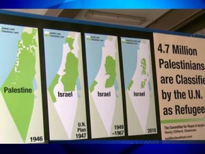

*A belief emettor: a controversial map exhibited in American train stations, also brandished by pro-Palestinian demonstrators (and also used by Pierre Stambul as the cover picture of his recent book “Le sionisme en questions”).*

## Modelling the dynamics of beliefs

I’m mathematician and I wondered how could we model the dynamics of a belief and whether there already exist some works on this topic. Below I define a simplistic model of dynamics of beliefs, partially inspired by Asu Ozdaglar’s slides [Dynamics of Beliefs, Culture, and Social Interactions](https://community.apan.org/afosr/m/trust__influence_program_review/121305/download.aspx) I found. I implement it using the R programming language. If you are not interested in the implementation, then skip all the framed boxes hereafter.

### Society as a graph

Consider for illustration a small society with $5$ individuals named `JP`, `AA`, `J`, `B` and `JBM`. It is represented by a graph such as the one below. The vertices are the individuals and the edges are the connections between individuals.

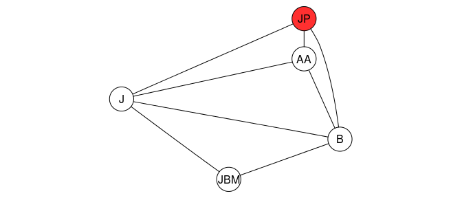

This graph is easy to plot in R using the `graph` and `Rgraphviz` packages. One starts with a matrix of connections `M`:

```r
M
```

```
##    AA  J  B JBM
## JP  1  1  1   0
## AA NA  1  1   0
## J  NA NA  1   1
## B  NA NA NA   1
```

prettier rendered like this (for those who are not familiar with R outputs):

$\begin{array}{r|c|c|c|c} & AA & J & B & JBM \\ \hline JP & 1 & 1 & 1 & 0 \\ \hline AA & & 1 & 1 & 0 \\ \hline J & & & 1 & 1 \\ \hline B & & & & 1 \\ \end{array}$

A `0` means no connection between the two individuals, a `1` means there’s a connection between the two individuals (connected individuals meet sometimes). Then the graph is constructed and plotted by the following code:

```r
library(Rgraphviz)
g <- new("graphNEL", nodes=members, edgemode="undirected")
for(i in 1:nrow(M)){
  connections <- which(M[i,]>0)
  if(length(connections)){
    for(j in connections){
      g <- addEdge(rownames(M)[i], colnames(M)[j], g, M[i,j])
    }
  }
}
g <- layoutGraph(g)
nodeRenderInfo(g) <- list(fill=c("JP"="firebrick1"))
renderGraph(g)
```

Individual `JP` will play a special role, that’s why we use a color for his vertex.

For fun, we can generate an interactive Javascript graph with the `d3Network` package:

```r
library(d3Network)
from <- sapply(str_split(edgeNames(g), "~"), function(pair) pair[1])
to <- sapply(str_split(edgeNames(g), "~"), function(pair) pair[2])
d3SimpleNetwork(data.frame(from,to), file="d3graph.html",
                fontsize=13, linkDistance=150,
                iframe=TRUE, width=400, height=300)
```

[interactive chart not shown]

### Belief updating

Consider a topic of interest in the society. Each individual has its own opinion about this topic, represented by a score between $0\%$ and $100\%$.  
When two connected individuals meet, their opinion is updated according to a *trusting parameter*. More precisely, denote by $x_i(t)$ the opinion of each individual $i$ at time $t$. Then, when individual $i$ meet individual $j$ at time $t$, its opinion is updated according to the following rule: $x_i(t^+) = (1-\alpha_{ij}) x_i(t) + \alpha_{ij} x_j(t)$ where $\alpha_{ij} \in [0,1]$ is the trusting parameter representing the degree of individual $i$ confidence in individual $j$. In other words, the updated opinion $x_i(t^+)$ is the average of the two opinions $x_i(t)$ and $x_j(t)$ weighted by the trusting parameter $\alpha_{ij}$.  
It is understood that individual $j$ opinion is similarly updated: $x_j(t^+) = (1-\alpha_{ji}) x_j(t) + \alpha_{ji} x_i(t)$

Extreme trusting parameters:

- $\alpha_{ij}=0$ *($i$ stubborn to $j$)*: in case $\alpha_{ij}=0$, opinion of individual $i$ does not change when he meets individual $j$
- $\alpha_{ij}=1$ *($i$ dominated by $j$)*: in case $\alpha_{ij}=1$, opinion of individual $i$ becomes opinion of individual $j$ when they meet

For our illustration we use the following matrix of trusting parameters (there’s no trusting parameter between unconnected individuals):

```r
alpha
```

```
##      JP  AA   J   B JBM
## JP   NA 0.0 0.0 0.0  NA
## AA  1.0  NA 0.9 0.9  NA
## J   0.6 0.1  NA 0.1 0.1
## B   1.0 0.5 0.5  NA 0.2
## JBM  NA  NA 0.2 0.0  NA
```

$\alpha=\begin{array}{r|c|c|c|c|c} & JP & AA & J & B & JBM \\ \hline JP & & 0.0 & 0.0 & 0.0 & \\ \hline AA & 1.0 & & 0.9 & 0.9 & \\ \hline J & 0.6 & 0.1 & & 0.1 & 0.1 \\ \hline B & 1.0 & 0.5 & 0.5 & & 0.2 \\ \hline JBM & & & 0.2 & 0.0 & \\ \end{array}$

and we use the following initial values of the opinions at time $t=0$:

```r
individuals <- colnames(alpha)
inits <- setNames(c(100, 50, 10, 5, 15), individuals)
inits
```

```
##  JP  AA   J   B JBM
## 100  50  10   5  15
```

Well, let me mention that this example is a joke inspired by an episode of my personal life. The belief of interest is “*Gilbert PC is crazy*” , but it has no importance for the purpose.

### Occurences of meetings

We simulate the occurences of meetings between individuals as simple as possible: at regular time intervals, we pick at random one connection between a pair of individuals among all possible connections.

```r
T <- 200
X <- matrix(NA, nrow=nrow(alpha), ncol=T)
rownames(X) <- rownames(alpha)
X[,1] <- inits
update <- function(X, t){
  edge <- str_split(edgeNames(g), "~")[[sample.int(numEdges(g),1)]]
  i <- edge[1] ; j <- edge[2]
  xi <- X[i,t-1] ; xj <- X[j,t-1]
  X[i,t] <- (1-alpha[i,j])*xi + alpha[i,j]*xj
  X[j,t] <- (1-alpha[j,i])*xj + alpha[j,i]*xi
  others <- setdiff(rownames(X), edge)
  X[others,t] <- X[others,t-1]
  return(X)
}
for(t in 2:T){
  X <- update(X,t)
}
```

### Results

```r
sims <- data.frame(time=1:T, t(X))
ggdata <- melt(sims, id.vars="time", variable.name="individual", value.name="opinion")
ggplot(ggdata, aes(x=time, y=opinion, color=individual)) +
   geom_line() +
  xlim(c(1,T)) + ylim(c(0,100))
```

[output not shown]

Every opinion converges to the opinion of the stubborn `JP`. The remarkable point is the behavior of `JBM` opinion: although `JBM` is not connected to the stubborn `JP` and is not a credulous individual, his opinion converges to the stubborn opinion in the long-term.

### A two-stubborns example

Let’s modify the trusting parameters of `JBM` as well as his initial opinion value. We set all to $0$, so that `JBM` is now the subborn opposite to `JP`.

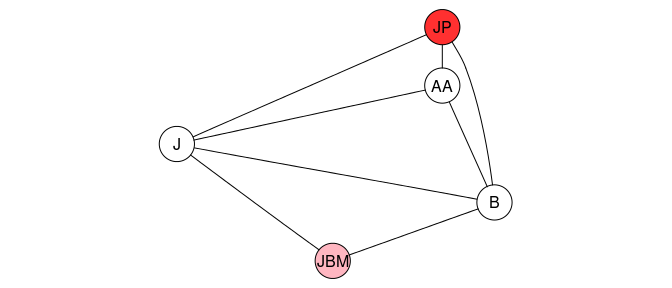

```r
inits["JBM"] <- 0
alpha["JBM","J"] <- 0
nodeRenderInfo(g) <- list(fill=c("JBM"="lightpink"))
renderGraph(g)
```

Let’s run the simulations until $T=1000$ this time:

```r
T <- 1000
X <- matrix(NA, nrow=nrow(alpha), ncol=T)
rownames(X) <- rownames(alpha)
X[,1] <- inits
for(t in 2:T){
  X <- update(X,t)
}
sims <- data.frame(time=1:T, t(X))
ggdata <- melt(sims, id.vars="time", variable.name="individual", value.name="opinion")
ggplot(ggdata, aes(x=time, y=opinion, color=individual)) +
   geom_line() +
  xlim(c(1,T)) + ylim(c(0,100))
```

[output not shown]

## Back to the real life

What is the interest of my simplistic model ? Nothing except as a starting point to ask ourselves some questions which should help to understand how it works in reality :

- Generally speaking, how could one improve the model so that it better reflects reality ?
- It is hard to imagine there is a realistic score representing our opinion. But this does not prevent us to imagine how such a fictive score would be updated after a contact from a qualitative perspective: when does it increase or decrease, when does it not move, can it definitely become immobile ?..
- What are your own trusting parameters in real life ? Why do you trust a media or a guy more than another one ? Is it due to its reputation ? Its charisma ? Its assurance ? Because it thinks like the majority ? Think that the guy you trust is also a guy trusting someone. Don’t doubt only about him, also doubt about yourself.
- How could one significantly change the trend of the dynamics of beliefs in a society ?

I don’t address these issues here, I just invite you to do so. And I wanted to say that mathematical modelling, by requiring first of all to identify the main mechanisms of the phenomenon, is a good way to go for anyone who wants to seriously reflect on this phenomenon.